# R Notebook

```r
library(tidyverse)
library(ggplot2)
```

En este tutorial entenderemos los conseptos acerca del algoritmo K vecinos cercanos (k-Nearest Neighbor) o simplemente KNN.

Quizas este sea uno de los algoritmos mas sencillos, esta fundamentado en conseptos basicos, de hecho muchos autores hacen llamar a este algoritmos como un algoritmo de **aprendizaje flojo**(lazy learning), ya que en un sentido estricto el algoritmo no esta aprendiendo, y tampoco ocurre una abstraccion como tal, lo que sucede es que en la fase de entrenamiento simplemente almacena datos, por lo que no surje una abstraccion del modelo, simplemente **memoriza** de tal manera que el aprendizaje sucede por memorizacion, haciendo muy lenta la fase de prediccion.

Sin embargo es un algoritmo muy utilizado para la clasificación ya que tiene muy buenas caracteristicas que ayudan a dar un primer vistazo a los datos e inclusive ser el algoritmo principal.

Veamos algunas de sus fortalezas y debilidades

| Fortalezas | Debilidades |
| --- | --- |
| Simple y efectivo | Al no producir un modelo es dificil seguir como las variables se relacionan con las clases |
| No es muy necesario hacer suposiciones de los datos | Requiere una selección apropiada del valor K |
| Face de entrenamiento rapida | Fase de clasificacion lenta |
|  | Variables nominales y datos faltantes requiren de un trato especial |

## Definiendo el modelo

Muy bien ya esplicamos las debilidades y bondades del algoritmo ahora toca explicar como funciona.

Imaginemos que deseamos clasificar una nueva observación (punto negro) y existen tres posibles clases

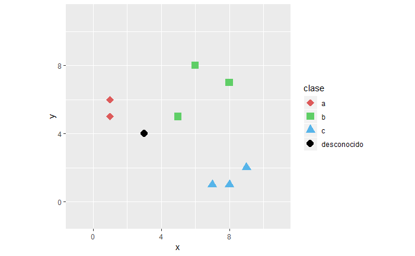

### Paso uno

Debemos calcular la distancia de este nuevo punto (observación) hacía todos los otros puntos ya etiquetados con su clase correspondiente y las ordenamos de menor a mayor.

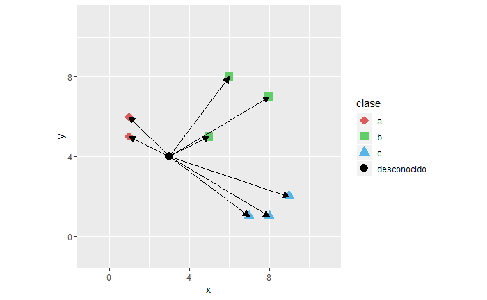

| dist | clase |
| --- | --- |
| 2.236068 | a |
| 2.236068 | b |
| 2.828427 | a |
| 5.000000 | b |
| 5.000000 | c |
| 5.830952 | b |
| 5.830952 | c |
| 6.324555 | c |

### Paso dos

Ya que tenemos las distancias ordenadas de menor a mayor basta con tomar los mas cercanos al punto a clasificar, lo cual esta determinado con el valor K seleccionado, digamos que para este ejemplo el valor de K es 3

| dist | clase |
| --- | --- |
| 2.236068 | a |
| 2.236068 | b |
| 2.828427 | a |

### Paso tres

Ahora solo basta con observar la clase que mas se repite en los K vecinos seleccionados y !Felicidades! hemos clasificado la nueva observación.

| clase | n |
| --- | --- |
| a | 2 |
| b | 1 |

En este ejemplo vemos que el que mas se repite es la clase **a** por lo tanto nuestra figura pertenece a esta clase.

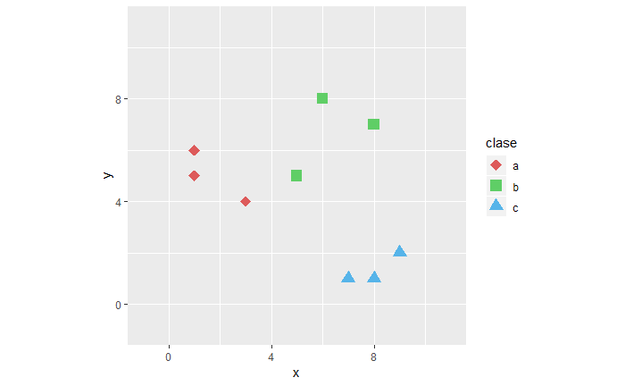

### Distancias

Es importante mencionar que para el ejemplo anterior la forma en la que medimos las distancias fue mendiante la distancia Euclidiana

$\sqrt{\sum_{i=1}^{m}(x_{i}-y_{i})^{2}}$

la cual es la mas utilizada sin embargo tambien se puede calcular mediante distancia Manhattan

$\sum_{i=1}^{m}\left | x_{i}-y_{i} \right |$

o mediante la distancia Hamming usualmente para identificar si un valor a cambiado o se mantiene igual

si $x=y$ entonces la distancia es igual a $0$

si $x\neq y$ entonces la distancia es igual a $1$

| x | y | distancia |
| --- | --- | --- |
| perro | perro | 0 |
| perro | gato | 1 |

### Valor de k

Optimizar el valor de K es de suma importancia, ya que al elejir un k valor muy pequeño es posible que el ruido de los datos tome importancia, por otro lado si el valor de k es alto la clase que sea mayoria tendre un peso importante.

Acontinuacion explicare graficamente lo anterior.

#### k-valor paqueño (overfitting)

Imaginemos el siguiente caso:

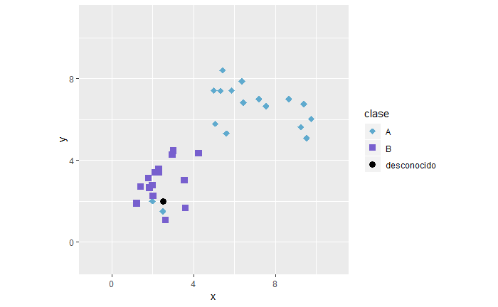

De elegir un k-valor de 3 la nueva observacion sera colocado en la clase **A** aunque visualmente es evidente que pertenece a la clase **B**, sin embargo aquí es donde el **ruido toma importancia**, y se dice que el modelo esta sobre ajustado.

#### k-valor alto (underfitting)

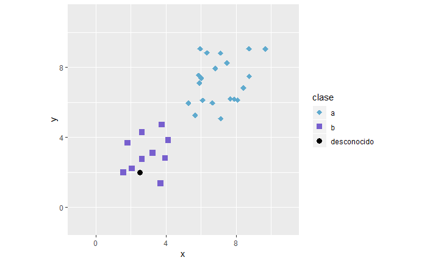

Por otra parte si tomamos el otro extremo donde k es igual al total de los datos, pasara el subajuste del algoritmo, ya que visualmente el punto desconocido pertenece a la clase **B** al ser la clase **A** mayoria sera clasificado dentro de esta.

Al analizar los extremos (k muy pequeño y k muy alto) es clara la importancia de un k-valor adecuado, normalmente se escoge como un buen valor de inicio la raiz cuadrada del numero de datos para el entrenamiento, sim embargo es buena practica tomar varios valores de k, y observar cual de estos es el que nos da una mejor clasificacion de los datos de entrenamiento.

# Clasificación de frutas

Ahora toca hacer un clasificar de alimentos usando el algoritmo KNN.

Crearemos los datos

```r
vegetales <- data.frame(nombre = c("zanahoria","apio","ejote","pepino","lechuga"),
                        dulzura = c(6,3,4,2,1),
                        crujiente = c(10,10,7,8,9),
                        tipo = "vegetal"
                        )
frutas <- data.frame(nombre = c("manzana","platano","uva","naranja","pera"),
                        dulzura = c(10,9,9,8,10),
                        crujiente = c(9,1,5,3,6),
                        tipo = "fruta"
                        )
proteina <- data.frame(nombre = c("tocino","queso","nuez","camarón","pescado"),
                        dulzura = c(1,1,3,2,3),
                        crujiente = c(4,1,5,3,2),
                        tipo = "proteina"
                        )
alimentos <- rbind(vegetales,frutas,proteina)
```

Como vemos tenemos tres clases(*tipo*) **vegetales, frutas y proteinas**, cada uno de los alimentos tiene una calificación que se encuentra entre 1 y 10, califican que tan crujientes y dulces son.

Graficamente estarian representados de la siguiente manera

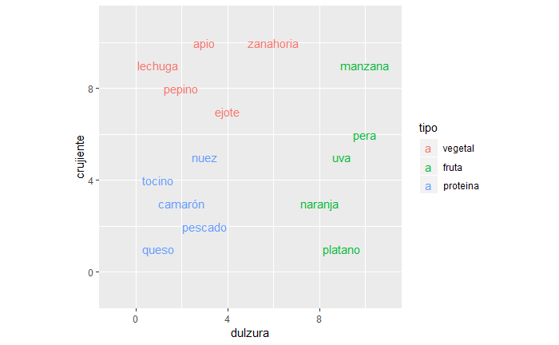

Pero ¿Y un tomate? ¿a que clase pertence? Veamoslo

```r
tomate <- data.frame(nombre = "tomate",
                        dulzura = 6,
                        crujiente = 4,
                        tipo = "desconocido"
                        )
```

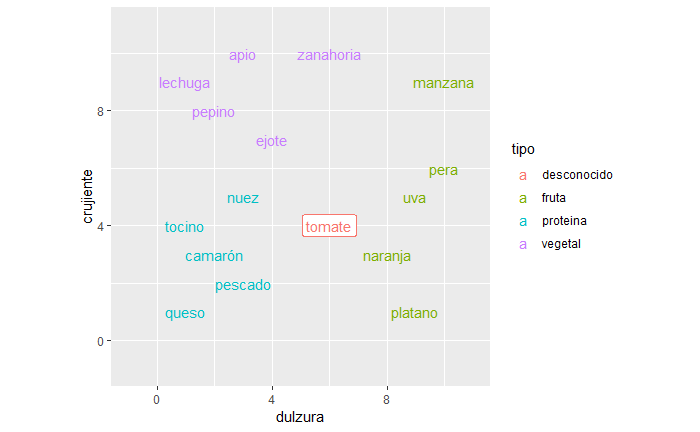

Crearemos una función que nos ayudara a calcular la distancía que existe de un punto a todos los demas

```r
dist <- function(point,data){

  sqrt((point[1]-data[,1])^2+
       (point[2]-data[,2])^2)
}
```

Ahora calculemos todas las distancias a nuestro tomate y ordenemoslo

```r
distancias <- data.frame(nombre = alimentos$nombre,
                          tipo = alimentos$tipo,
                          dist=dist(point = c(6,4),data = alimentos[,2:3]))%>%
   arrange(dist)

knitr::kable(distancias)
```

| nombre | tipo | dist |
| --- | --- | --- |
| naranja | fruta | 2.236068 |
| uva | fruta | 3.162278 |
| nuez | proteina | 3.162278 |
| ejote | vegetal | 3.605551 |
| pescado | proteina | 3.605551 |
| camarón | proteina | 4.123106 |
| platano | fruta | 4.242641 |
| pera | fruta | 4.472136 |
| tocino | proteina | 5.000000 |
| pepino | vegetal | 5.656854 |
| queso | proteina | 5.830952 |
| zanahoria | vegetal | 6.000000 |
| manzana | fruta | 6.403124 |
| apio | vegetal | 6.708204 |
| lechuga | vegetal | 7.071068 |

la siguiente función nos regresara la clase correspondiente al K valor seleccionado

```r
resultado <- function(distancias,k) {
  result <- head(distancias,k) %>%
    group_by(tipo) %>%
    summarise(n = n()) %>%
    arrange(desc(n))

  cat("Pertenece a" ,as.character(result$tipo[1]) )
}
```

```r
resultado(distancias,4)
```

```
Pertenece a fruta
```

Genial nuestro tomate es una fruta! :D

Ahora metamos todo en la funcion clasificador y veamos que sucede al clasificar un Piña.

```r
clasificador <- function(point,dataframe,k) {
  distancias <- data.frame(nombre = alimentos$nombre,
                          tipo = alimentos$tipo,
                          dist=dist(point=point,alimentos[,2:3])) %>%
    arrange(dist)

  resultado(distancias,k)
}
```

```r
clasificador(c(8,4),alimentos,4)
```

```
Pertenece a fruta
```